# Road accidents data analysis

Ahmed A. Radhi, Khalid Talal Suliman

3/13/2021

```r
library(tidyverse)
```

# Task 1

```r
# Loading the data into R
Accidents_2017 <- read_csv("Data/datagov-uk-6efe5505-941f-45bf-b576-4c1e09b579a1/2017-8.csv",
col_names = c("Reference_Number","Easting","Northing","Vehicles_Num","Accident_Date","Time","Road_Class","Road_Surface",
              "Lightning_Cond","Weather_Cond","Vehicle_Type","Casualty_Class","Severity","Gender","Age"), skip = 1)
# Parsing the data
Accidents_Date <- Accidents_2017$Accident_Date
Accidents_Date <- parse_date(Accidents_Date, "%m/%d/%Y")

Time <- Accidents_2017$Time
Time <- parse_time(Time, "%H%M")

# Adding the new columns to the tibble.
Accidents_2017 <- Accidents_2017 %>%
  select(1:4, 7:15) %>%
  mutate(Accidents_Date, Time)

Accidents_2017 <- Accidents_2017[,c(1:4,14,15,5:13)]
```

```r
str(Accidents_2017)
```

```
## tibble [2,203 x 15] (S3: tbl_df/tbl/data.frame)
##  $ Reference_Number: chr [1:2203] "3AP0313" "3BE0850" "4110858" "4110858" ...
##  $ Easting         : num [1:2203] 426340 430828 428940 428940 429899 ...
##  $ Northing        : num [1:2203] 428455 433222 429856 429856 434277 ...
##  $ Vehicles_Num    : num [1:2203] 1 2 2 2 2 2 3 3 2 2 ...
##  $ Accidents_Date  : Date[1:2203], format: "2017-03-17" "2017-01-14" ...
##  $ Time            : 'hms' num [1:2203] 08:15:00 13:30:00 08:05:00 08:05:00 ...
##   ..- attr(*, "units")= chr "secs"
##  $ Road_Class      : chr [1:2203] "A643" "A61" "A653" "A653" ...
##  $ Road_Surface    : chr [1:2203] "Dry" "Dry" "Wet/Damp" "Wet/Damp" ...
##  $ Lightning_Cond  : chr [1:2203] "Daylight: Street lights present" "Daylight: Street lights present" "Daylight: Street lights present" "Daylight: Street lights present" ...
##  $ Weather_Cond    : chr [1:2203] "Other" "Fine without high winds" "Fine without high winds" "Fine without high winds" ...
##  $ Vehicle_Type    : chr [1:2203] "Car" "Pedal cycle" "Car" "Car" ...
##  $ Casualty_Class  : chr [1:2203] "Pedestrian" "Driver or rider" "Driver or rider" "Driver or rider" ...
##  $ Severity        : chr [1:2203] "Serious" "Slight" "Slight" "Slight" ...
##  $ Gender          : chr [1:2203] "Female" "Male" "Male" "Male" ...
##  $ Age             : num [1:2203] 61 36 32 30 26 34 39 69 18 17 ...
```

We have 2,203 observations, 15 variables (with `Age` and `Road_Surface` as examples of continuous and categorical variables, respectively), and we have times and dates in the `Accidents_Date` and `Time` variables. This satisfies the data requirements for the MATH 214 project.

## Description

The dataset shows information on road accidents across Leeds during the year 2017.

Reference_Number : Reference number of the accident

Easting : X-coordinate of the location of the accident using grid coordinates

Northing : Y-coordinate of the location of the accident using grid coordinates

Vehicles_Num : Number of vehicles involved in the accident

Accident_Date : Date of the accident

Time : Time of the accident

Road_Class : Class of road on which the accident happened

Road_Surface : Surface of the road during the accident

Lightning_Cond : Light conditions during the accident

Weather_Cond : Weather conditions during the accident

Vehicle_Type : Type of vehicle that caused the accident

Casualty_Class : Class of the casualty

Severity : Degree of severity of the accident

## Reference

https://data.world/datagov-uk/6efe5505-941f-45bf-b576-4c1e09b579a1

# Task 2

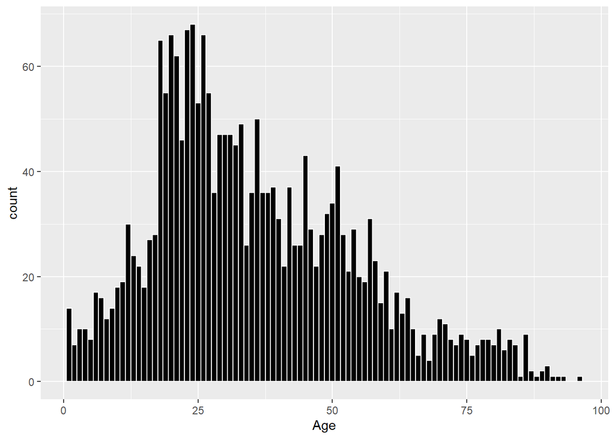

```r
# Variance

ggplot(data = Accidents_2017, mapping= aes(x=Age)) +
  geom_histogram(binwidth = 1,fill="black", color = "white")
```

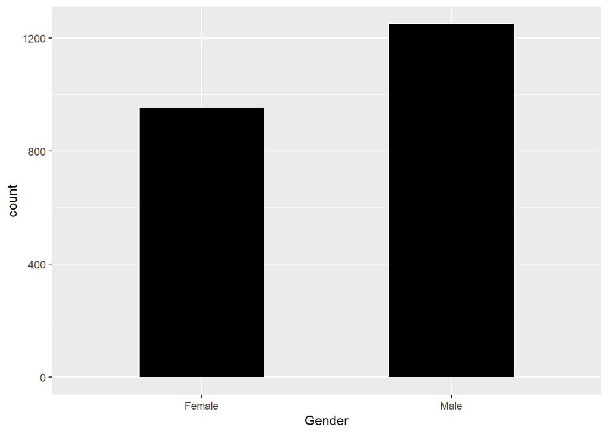

```r
# Variance

ggplot(data = Accidents_2017, mapping = aes(x=Gender)) +
  geom_bar(fill = "black" , width = 0.5)
```

```r
Accidents_2017 %>%
  group_by(Age) %>%
  summarise(count = n())
```

```
## # A tibble: 94 x 2
##      Age count
##  * <dbl> <int>
##  1     1    14
##  2     2     7
##  3     3    10
##  4     4    10
##  5     5     8
##  6     6    17
##  7     7    16
##  8     8    12
##  9     9    14
## 10    10    18
## # ... with 84 more rows
```

```r
Accidents_2017 %>%
  group_by(Gender) %>%
  summarise(count = n())
```

```
## # A tibble: 2 x 2
##   Gender count
## * <chr>  <int>
## 1 Female   953
## 2 Male    1250
```

```r
Accidents_2017 %>%
  group_by(Accidents_Date) %>%
  summarise(count = n())
```

```
## # A tibble: 360 x 2
##    Accidents_Date count
##  * <date>         <int>
##  1 2017-01-01         4
##  2 2017-01-02         7
##  3 2017-01-03         3
##  4 2017-01-04         7
##  5 2017-01-05         4
##  6 2017-01-06         5
##  7 2017-01-07         5
##  8 2017-01-09         5
##  9 2017-01-10         9
## 10 2017-01-11         7
## # ... with 350 more rows
```